# EMBL-EBI Cancer genomics and transcriptomics course: Clonality analysis

Francesc Muyas, PhD

11/07/2023

# Clonal population structure in cancer genomes

A cancer ‘clone’ remains a loosely defined entity, and its purest definition is ‘a group of cells within the tumour that share a common ancestor’. However, is implies that any ancestor in the entire phylogenetic tree of a tumour can be identified as the founder (clone), even though it may show no biological difference from the rest of the cancer cells. This is why, in the field, we implicitly identify clones of interest, such as those that have growth/survival advantage.

In this lecture, we will explore the interpretation of the clonality of somatic mutations to gain insights into the clonal structure of cancer genomes.

We will use COLO829 mutations and other generated data, which can downloaded from https://github.com/cortes-ciriano-lab/CancerGenomicsCourse_EMBL-EBI.

In addition, we will mainly work with the R package [Mobster](https://caravagnalab.github.io/mobster/index.html).

### Preparing and loading the data

### Required packages

```r
#---
# Loading required packages
#---
suppressWarnings(library(data.table))
suppressWarnings(library(ggplot2))
suppressWarnings(library(mobster))
suppressWarnings(library(GenomicRanges))
suppressWarnings(library(dmr.util))
```

### Loading data

#### Somatic mutations (SNVs)

We will load pre-processed mutation calls. **Please edit the path of FOLDER to the path of your data**

```r
#----
# Loading data
#----
FOLDER <- '~/Documents/EMBL/CancerGenomicsCourse2023/clonality_analysis_data/'
files <- list.files(path = FOLDER, pattern =  "*muts.tsv",recursive = T)
files <- paste(FOLDER, files, sep = '/')

All_muts <- NULL
for (file in files){
  TEMP <- as.data.frame(fread(file))
  All_muts <- rbind(All_muts,TEMP)
}

head(All_muts)
```

```
##    sampleID CHROM    POS REF ALT T_ALT_COUNT T_REF_COUNT T_DP     T_VAF
## 1 COLO829.2  chr1 183198   C   T          24         132  159 0.1509434
## 2 COLO829.2  chr1 629218   A   G           7          28   39 0.1794872
## 3 COLO829.2  chr1 632106   T   C           7          25   32 0.2187500
## 4 COLO829.2  chr1 632109   T   C           7          24   31 0.2258065
## 5 COLO829.2  chr1 794320   C   T          17          62   80 0.2125000
## 6 COLO829.2  chr1 887559   C   T          78          30  109 0.7155963
```

#### Somatic copy number calls

We will load pre-processed copy number calls. **Please edit the path of FOLDER to the path of your data**

```r
#----
# Loading copy number calls
#----
CN <- '~/Documents/EMBL/CancerGenomicsCourse2023/clonality_analysis_data/COLO829T.CN_purple.tsv'
CN <- as.data.frame(fread(CN))

head(CN)
```

```
##   chromosome    start      end copyNumber bafCount observedBAF    baf
## 1       chr1        1   791524          3        0      0.0000 0.7373
## 2       chr1   791525 24448676          3     4279      0.7113 0.7128
## 3       chr1 24448677 24448688          5        0      0.0000 0.8490
## 4       chr1 24448689 29553843          3      773      0.7076 0.7092
## 5       chr1 29553844 29553844          9        0      0.0000 0.9065
## 6       chr1 29553845 33814477          3      541      0.7132 0.7147
##   segmentStartSupport segmentEndSupport             method depthWindowCount
## 1            TELOMERE               SGL STRUCTURAL_VARIANT                0
## 2                 SGL               SGL       BAF_WEIGHTED            19611
## 3                 SGL               SGL STRUCTURAL_VARIANT                0
## 4                 SGL               SGL       BAF_WEIGHTED             4655
## 5                 SGL               INF STRUCTURAL_VARIANT                0
## 6                 INF               SGL       BAF_WEIGHTED             4020
##   gcContent minStart maxStart minorAlleleCopyNumber majorAlleleCopyNumber
## 1    0.0000        1        1                     1                     2
## 2    0.4876        1   791525                     1                     2
## 3    0.0000 24448677 24448677                     1                     4
## 4    0.4739 24448689 24448689                     1                     2
## 5    0.0000 29553844 29553844                     1                     8
## 6    0.4727 29553845 29553845                     1                     2
##   Ploidy Purity
## 1    3.1      1
## 2    3.1      1
## 3    3.1      1
## 4    3.1      1
## 5    3.1      1
## 6    3.1      1
```

### Intersecting SNV coordinates with CNA coordinates

This step is required to map the copy number calls to the somatic SNVs. We need to know the total, major and minor copy number for each mutation.We can do this with the *GenomicRanges* R package.

```r
#----
# Intersecting mutations with copy number calls
#----
# Intersecting copy number calls with individual mutations
VCF_bed <- with(All_muts, GRanges(CHROM, ranges=IRanges(POS-1, POS))) # Get the GRanges object from the VCF
CN_bed <- with(CN, GRanges(chromosome, ranges=IRanges(start, end), Total_CN = copyNumber, Major_CN = majorAlleleCopyNumber, Minor_CN = minorAlleleCopyNumber))

# Intersecting both bed files
o1 <- findOverlaps(VCF_bed,CN_bed)
HITS1 <- CN_bed[subjectHits(o1)]
DF1 <- VCF_bed[queryHits(o1)]
DF1 <- as.data.frame(DF1)
HITS2 <- as.data.frame(HITS1)
HITS2$CNA_coordinates <- paste(HITS2$seqnames,HITS2$start,HITS2$end, sep = '-')
DF2 <- cbind(DF1,HITS2)
DF2 <- DF2[,c('seqnames','end','CNA_coordinates','Total_CN','Major_CN','Minor_CN')]
colnames(DF2) <- c('CHROM','POS','CNA_coordinates','Total_CN','Major_CN','Minor_CN')
DF2 <- unique(DF2)

# Merge both files (VCF and CN)
All_muts2 <- merge(All_muts,DF2,by=c('CHROM','POS'),all.x = T)

# We only will analyse the autosomal chromosomes
# Sex chromosomes might have different ploidy levels, so we will ignore them for this analysis
All_muts2 <- All_muts2[All_muts2$CHROM %in% paste('chr',seq(1,22), sep = ''),]

# We already know the cancer purity of these samples
# As it is a cancer cell line (also calulated with copy number algorithms), it has a purity == 1
All_muts2$Purity <- 1

head(All_muts2)
```

```
##   CHROM       POS  sampleID REF ALT T_ALT_COUNT T_REF_COUNT T_DP     T_VAF
## 1  chr1 100083317 COLO829.3   A   T          71           2   74 0.9594595
## 2  chr1 100083317 COLO829.2   A   T          71           2   74 0.9594595
## 3  chr1 100083317  COLO829T   A   T          71           2   74 0.9594595
## 4  chr1 100180741 COLO829.3   C   T          45           1   47 0.9574468
## 5  chr1 100180741  COLO829T   C   T          45           1   47 0.9574468
## 6  chr1 100180741 COLO829.2   C   T          45           1   47 0.9574468
##           CNA_coordinates Total_CN Major_CN Minor_CN Purity
## 1 chr1-89317855-117973563        2        2        0      1
## 2 chr1-89317855-117973563        2        2        0      1
## 3 chr1-89317855-117973563        2        2        0      1
## 4 chr1-89317855-117973563        2        2        0      1
## 5 chr1-89317855-117973563        2        2        0      1
## 6 chr1-89317855-117973563        2        2        0      1
```

### Calculate Cancer Cell Fraction (CCF)

The cancer cell fraction (CCF) is a measure that represents the proportion of cancer cells carrying a specific mutation within a tumour sample.

For this calculation, we need the copy number calls (previously loaded), the purity (previously estimated, = 1), and the VAFs (included in the mutation table). However, we still to calculate the multiplicity

#### Multiplicity calculation

The multiplicty represents the number of genomic segments harbouring each mutation.

This is the function:

```r
# Multiplicity formula
ARGMIN_MULTIPLICITY <- function(VAF,mCN_T,MCN_T,TCN_T,TCN_N,purity){

  if (MCN_T > 0){
    MULTIPLICITY <- arg.min(seq(1,MCN_T,1), function(x) abs(VAF*(1/(purity*x))*(purity*TCN_T+(1-purity)*TCN_N) - 1))
    return(MULTIPLICITY)
  } else {
    return (NA)
  }

}
```

Now we apply this formula to all our mutations:

```r
# Multiplicity calculation
# A little bit of description
All_muts2$Multiplicity <- apply(All_muts2, 1, function(x) ARGMIN_MULTIPLICITY(VAF = as.numeric(x['T_VAF']),
                                                                    mCN_T = as.numeric(x['Minor_CN']),
                                                                    MCN_T = as.numeric(x['Major_CN']),
                                                                    TCN_T = as.numeric(x['Total_CN']),
                                                                    TCN_N = 2,
                                                                    purity = 1))

head(All_muts2)
```

```
##   CHROM       POS  sampleID REF ALT T_ALT_COUNT T_REF_COUNT T_DP     T_VAF
## 1  chr1 100083317 COLO829.3   A   T          71           2   74 0.9594595
## 2  chr1 100083317 COLO829.2   A   T          71           2   74 0.9594595
## 3  chr1 100083317  COLO829T   A   T          71           2   74 0.9594595
## 4  chr1 100180741 COLO829.3   C   T          45           1   47 0.9574468
## 5  chr1 100180741  COLO829T   C   T          45           1   47 0.9574468
## 6  chr1 100180741 COLO829.2   C   T          45           1   47 0.9574468
##           CNA_coordinates Total_CN Major_CN Minor_CN Purity Multiplicity
## 1 chr1-89317855-117973563        2        2        0      1            2
## 2 chr1-89317855-117973563        2        2        0      1            2
## 3 chr1-89317855-117973563        2        2        0      1            2
## 4 chr1-89317855-117973563        2        2        0      1            2
## 5 chr1-89317855-117973563        2        2        0      1            2
## 6 chr1-89317855-117973563        2        2        0      1            2
```

#### Cancer cell fraction calculation

This function will calculate the CCF:

```r
# Cancer Cell fraction calculation
CCF_calc <- function(VAF,Multiplicity,TCN_T,purity){
  if (TCN_T > 0){
    ccf <- VAF / (Multiplicity * purity) * (purity * TCN_T + 2*(1-purity))
    return(ccf)
  } else{
    return (NA)
  }
}
```

Once we have the multiplicity and the formula, we can calculate the **CCF** :

```r
# Cancer Cell fraction Calculation
All_muts2$CCF <- apply(All_muts2, 1, function(x) CCF_calc(VAF = as.numeric(x['T_VAF']),
                                                Multiplicity = as.numeric(x['Multiplicity']),
                                                TCN_T = as.numeric(x['Total_CN']),
                                                purity = 1))
```

Let’s take a look to the CCF estimations:

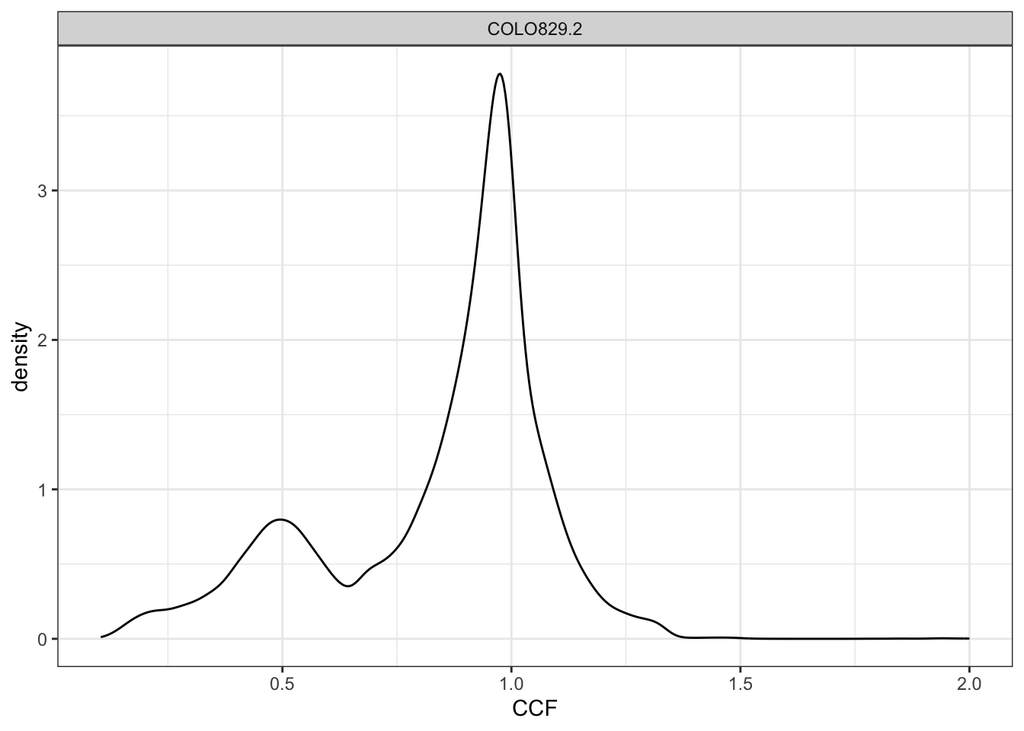

```r
ggplot(All_muts2[All_muts2$sampleID == 'COLO829.2',], aes(x = CCF))+
  geom_density() +
  facet_grid(.~sampleID) +
  theme_bw()
```

**Important** We have by far too many mutations for a fast and example computation of the CCF. For this reason, we do a random sampling of mutations:

```r
set.seed(1111)
All_muts2 <- All_muts2[sample(nrow(All_muts2), 15000), ]
```

## Inferring clones using Mobster

Clonal reconstruction from bulk sequencing data involves complex computational algorithms and statistical models. Today, we will use [Mobster](https://caravagnalab.github.io/mobster/index.html). Mobster is a package that implements a model-based approach for subclonal deconvolution of cancer genome sequencing data (Caravagna et al; PMID: 32879509).

### 1. Inferring clones in the original COLO829T sample

Since CCF values usually peak at around 1.0 for clonal mutations (i.e., present in 100% of the input cells), this tool suggests to adjust standard CCF estimates dividing them by 2 in order to reflect the peak of an heterozygous clonal mutation at 50% VAF for a 100% pure bulk sample. The results VAFs cannot be grater than 1.

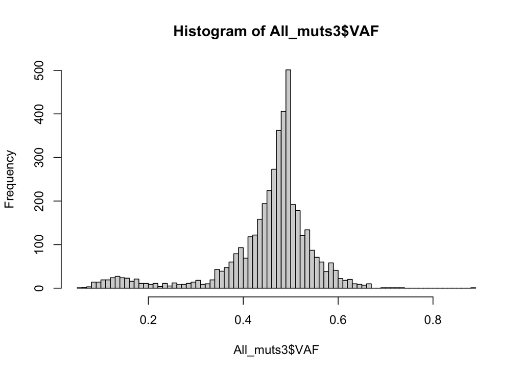

```r
set.seed(1111)
All_muts3 <- All_muts2[All_muts2$sampleID == 'COLO829T',]
All_muts3$VAF <- All_muts3$CCF/2
All_muts3 <- All_muts3[All_muts3$VAF < 1,]

hist(All_muts3$VAF, breaks = 100)
```

#### Fitting clones

Now, we can use the function *mobster_fit* to fit the clones here:

```r
fit1 = mobster_fit(
  All_muts3,
  K = 1:3,
  samples = 10,
  init = 'random',
  maxIter = 100,
  seed = 1111,
  N_cutoff = 50)
```

Let’s check the results of the best fit:

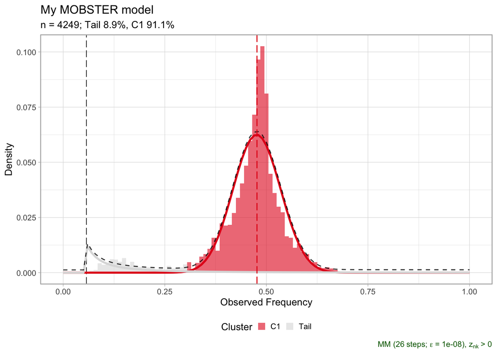

```r
best_fit1 <- fit1$best
plot(best_fit1)
```

#### Checking proportions of each clone

We can also check the proportion of mutations of each clone:

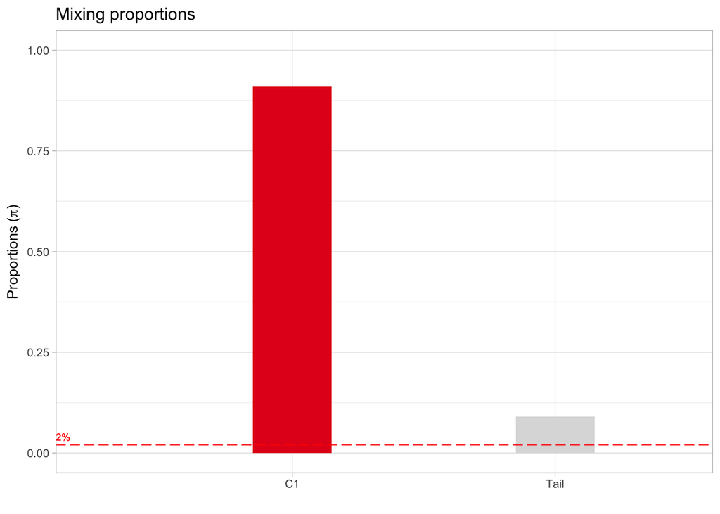

```r
plot_mixing_proportions(best_fit1)
```

You can finally access the metrics of our estimation:

```r
best_fit1$Clusters
```

```
## # A tibble: 10 × 4
##    cluster type              fit.value init.value
##    <chr>   <chr>                 <dbl>      <dbl>
##  1 Tail    Shape               0.838     4.46
##  2 Tail    Scale               0.0571    0.0571
##  3 Tail    Mean              Inf         0.0737
##  4 Tail    Variance          Inf         0.000494
##  5 C1      a                  35.5       9.18
##  6 C1      b                  38.9       9.18
##  7 C1      Mean                0.477     0.373
##  8 C1      Variance            0.00331   0.00912
##  9 Tail    Mixing proportion   0.0893    0.5
## 10 C1      Mixing proportion   0.911     0.5
```

Finally, you can recover the old mutation data frame with the clones already annotated:

```r
Muts_COLO829T <- best_fit1$data
head(Muts_COLO829T)
```

```
##        CHROM       POS sampleID REF ALT T_ALT_COUNT T_REF_COUNT T_DP     T_VAF
## 115730  chr5 152920167 COLO829T   C   T          59           0   61 0.9672131
## 25268  chr12  62948869 COLO829T   C   T          31          74  108 0.2870370
## 51000  chr18  53797882 COLO829T   T   G          33          56   89 0.3707865
## 28122  chr13 112248533 COLO829T   G   A          49          35   87 0.5632184
## 122029  chr6 139707611 COLO829T   G   A          52          29   83 0.6265060
## 71804  chr21  25362075 COLO829T   G   A          32          67  103 0.3106796
##                 CNA_coordinates Total_CN Major_CN Minor_CN Purity Multiplicity
## 115730 chr5-123640458-159924186        2        2        0      1            2
## 25268   chr12-56345504-62964910        3        2        1      1            1
## 51000   chr18-47600578-58880752        3        2        1      1            1
## 28122  chr13-94034252-112934555        3        2        1      1            2
## 122029 chr6-138453045-154454080        3        2        1      1            2
## 71804   chr21-20579949-35865630        3        2        1      1            1
##              CCF       VAF cluster
## 115730 0.9672131 0.4836066      C1
## 25268  0.8611111 0.4305556      C1
## 51000  1.1123596 0.5561798      C1
## 28122  0.8448276 0.4224138      C1
## 122029 0.9397590 0.4698795      C1
## 71804  0.9320388 0.4660194      C1
```

We can now plot with our previously calculated CCF:

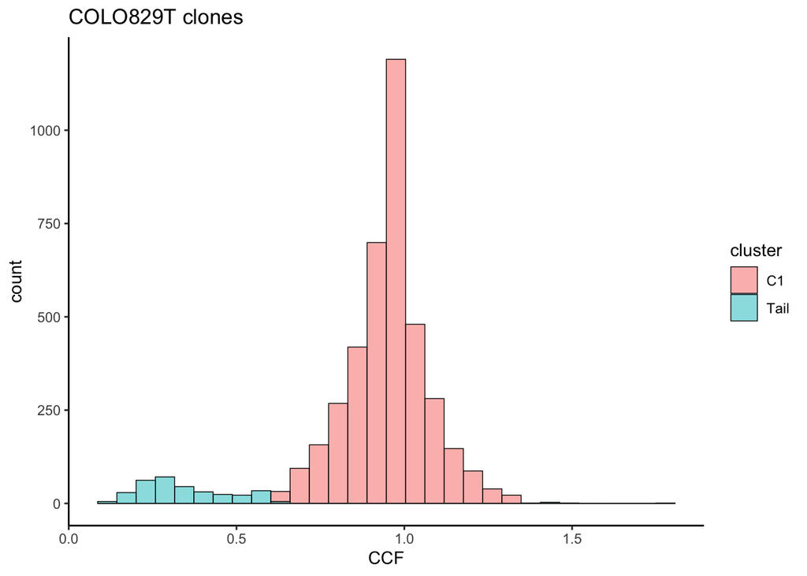

```r
ggplot(Muts_COLO829T, aes(x = CCF, fill = cluster))+
  geom_histogram(position="identity", alpha=0.5, color = 'black', size= 0.25)+
  labs(title = 'COLO829T clones')+
  theme_classic()
```

Since CCF values usually peak at around 1.0 for clonal mutations (i.e., present in 100% of the input cells), this tool suggests to adjust standard CCF estimates dividing them by 2 in order to reflect the peak of an heterozygous clonal mutation at 50% VAF for a 100% pure bulk sample. The results VAFs cannot be grater than 1.

First we check how the resulting VAFs look in this sample:

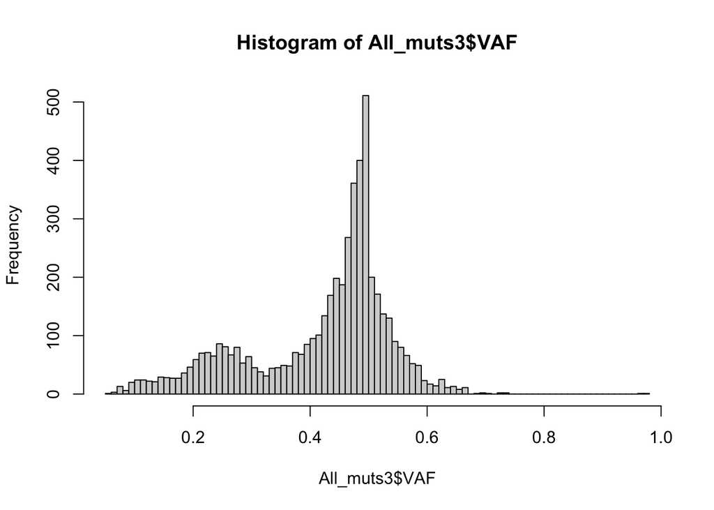

```r
set.seed(1111)
All_muts3 <- All_muts2[All_muts2$sampleID == 'COLO829.2',]
All_muts3$VAF <- All_muts3$CCF/2
All_muts3 <- All_muts3[All_muts3$VAF < 1,]

hist(All_muts3$VAF, breaks = 100)
```

#### Fitting clones

Now, we can use the function *mobster_fit* to fit the clones here:

```r
fit2 = mobster_fit(
  All_muts3,
  K = 1:3,
  samples = 10,
  init = 'random',
  maxIter = 100,
  seed = 1111,
  N_cutoff = 50)
```

Let’s check the results of the best fit:

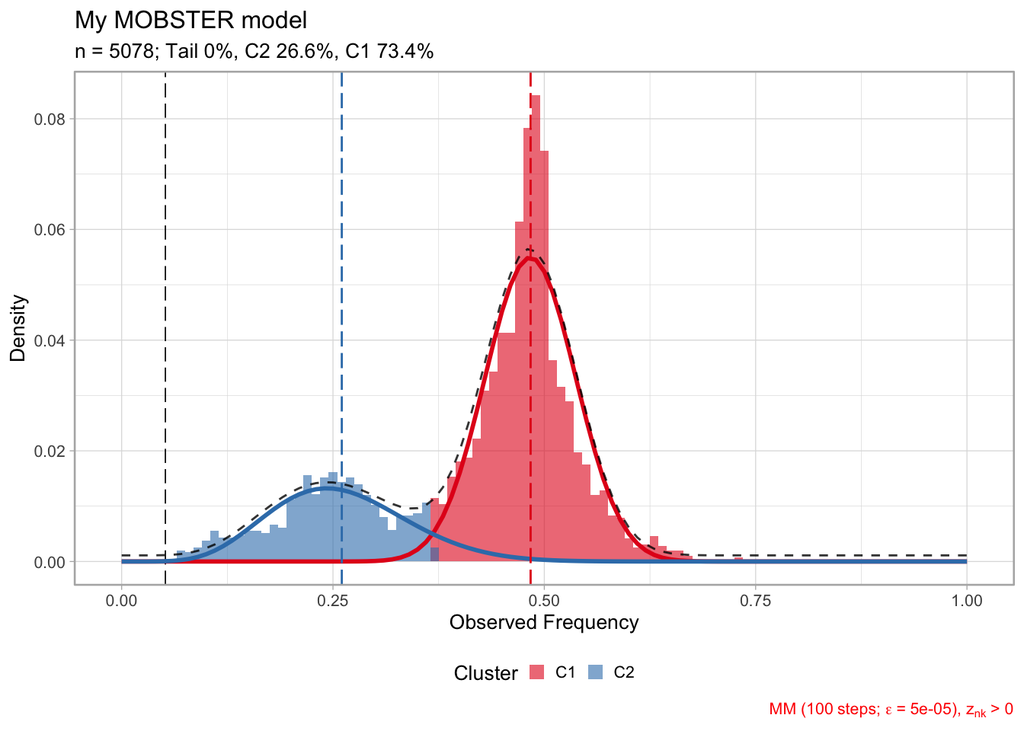

```r
best_fit2 <- fit2$best
plot(best_fit2)
```

#### Checking proportions of each clone

We can also check the proportion of mutations of each clone:

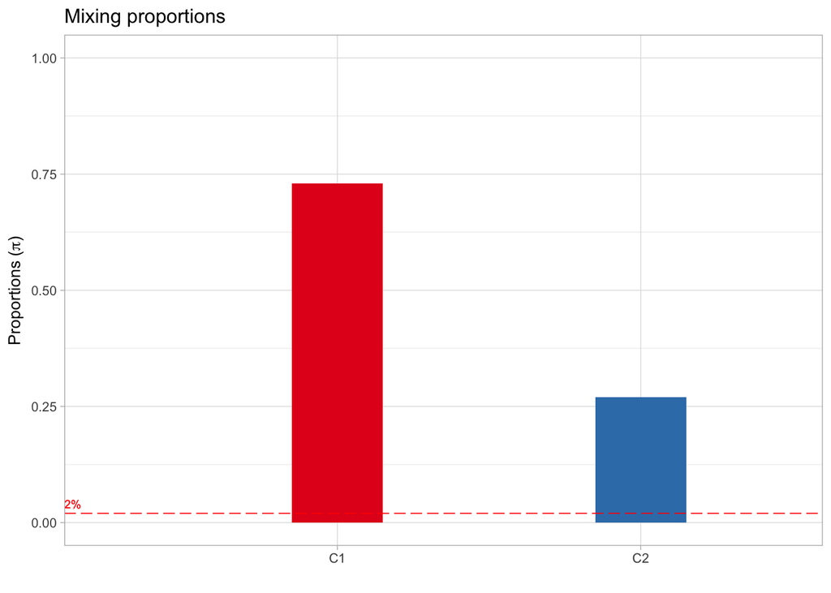

```r
plot_mixing_proportions(best_fit2)
```

You can finally access the metrics of our estimation:

```r
best_fit2$Clusters
```

```
## # A tibble: 11 × 4
##    cluster type              fit.value init.value
##    <chr>   <chr>                 <dbl>      <dbl>
##  1 C2      a                   7.62       0.0729
##  2 C2      b                  21.6        0.0729
##  3 C2      Mean                0.260      0.0247
##  4 C2      Variance            0.00636    0.00611
##  5 C1      a                  42.8       19.7
##  6 C1      b                  45.6       19.7
##  7 C1      Mean                0.484      0.613
##  8 C1      Variance            0.00279    0.00716
##  9 C2      Mixing proportion   0.266      0.333
## 10 C1      Mixing proportion   0.734      0.333
## 11 Tail    Mixing proportion   0         NA
```

Finally, you can recover the old mutation data frame with the clones already annotated:

```r
Muts_COLO829.2 <- best_fit2$data
head(Muts_COLO829.2)
```

```
##        CHROM       POS  sampleID REF ALT T_ALT_COUNT T_REF_COUNT T_DP     T_VAF
## 74719   chr3 102813711 COLO829.2   A   T          28         119  152 0.1842105
## 10445   chr1  84158409 COLO829.2   C   T          76          27  104 0.7307692
## 79718   chr3 195235761 COLO829.2   C   T          65          66  134 0.4850746
## 126565  chr6  77015411 COLO829.2   C   T          42          61  108 0.3888889
## 138509  chr8 131935606 COLO829.2   T   G          43          53  102 0.4215686
## 66738   chr2  82668577 COLO829.2   C   T          26          84  113 0.2300885
##                 CNA_coordinates Total_CN Major_CN Minor_CN Purity Multiplicity
## 74719   chr3-98196244-111993483        4        2        2      1            1
## 10445    chr1-81846370-86871328        3        2        1      1            2
## 79718  chr3-191583301-198295559        4        2        2      1            2
## 126565   chr6-66106227-82887393        3        2        1      1            1
## 138509 chr8-131341834-142185749        4        2        2      1            2
## 66738    chr2-70570582-82746050        3        2        1      1            1
##              CCF       VAF cluster
## 74719  0.7368421 0.3684211      C1
## 10445  1.0961538 0.5480769      C1
## 79718  0.9701493 0.4850746      C1
## 126565 1.1666667 0.5833333      C1
## 138509 0.8431373 0.4215686      C1
## 66738  0.6902655 0.3451327      C2
```

We can now plot with our previously calculated CCF:

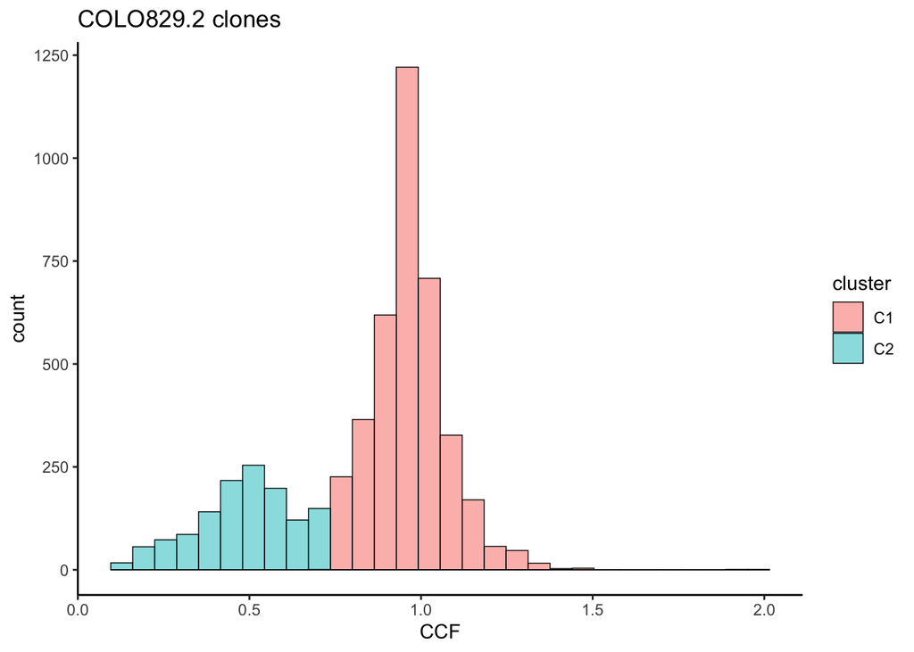

```r
ggplot(Muts_COLO829.2, aes(x = CCF, fill = cluster))+
  geom_histogram(position="identity", alpha=0.5, color = 'black', size= 0.25)+
  labs(title = 'COLO829.2 clones')+
  theme_classic()
```